# Experiment 2 - Analysis Pipeline

# 0. Setup & Libraries

```r
library(tidyverse)
library(rstan)
library(brms)
library(emmeans)
library(bayesplot)
library(kableExtra)
library(ggpubr)

# clear workspace
rm(list = ls())

# create relative folders if not exist
dir.create("model_outputs/statistical_modelling_brms/experiment_2", showWarnings = FALSE, recursive = TRUE)
dir.create("results/tables", showWarnings = FALSE, recursive = TRUE)
dir.create("results/figures", showWarnings = FALSE, recursive = TRUE)

# shared publication theme; keep data colours in each plot's manual scale
theme_paper = function(base_size = 16, aspect_ratio = 1) {
  theme_bw(base_size = base_size) +
    theme(plot.title = element_text(hjust = 0.5, size = 12),
          panel.grid.minor = element_blank(),
          panel.grid.major.x = element_blank(),
          panel.grid.major.y = element_line(colour = "grey90", linewidth = 0.3),
          panel.border = element_rect(fill = NA, colour = "grey70", linewidth = 0.4),
          text = element_text(colour = "#4A4A4A", family = "Helvetica"),
          axis.text = element_text(size = 9, colour = "#4A4A4A"),
          axis.title = element_text(size = 11),
          strip.text = element_text(size = 11, colour = "#4A4A4A", face = "bold"),
          strip.background = element_rect(fill = "grey96", colour = NA),
          aspect.ratio = aspect_ratio,
          plot.margin = margin(12, 8, 12, 4, "pt"),
          legend.position = "bottom",
          legend.title.align = 0.5,
          legend.text = element_text(size = 9),
          legend.title = element_text(size = 10))
}

voice_position = position_dodge(width = 0.18)
```

# 1. Data Loading & Exclusions

```r
D = readRDS("analysis_data/experiment_2_analysis.rds") %>%
  rename(SubjID = subject_nr,
         binary_resp = resp_binary) %>%
  mutate(SubjID = as.factor(SubjID))
cat(sprintf("Raw N = %d participants\n", length(unique(D$SubjID))))
```

```
## Raw N = 93 participants
```

```r
# remove people with low hit rate
d1 = D %>% filter(bad_subject_zerohit == 0)
cat(sprintf("hit-rate exclusion: N = %d\n", length(unique(D$SubjID))-length(unique(d1$SubjID))))
```

```
## hit-rate exclusion: N = 8
```

```r
# remove people with super fast RTs
RT = d1 %>%
  group_by(SubjID) %>%
  mutate(bad_RT = ifelse(RT < 150, 1, 0)) %>%
  summarise(bad_sub_RT = ifelse(mean(bad_RT) > 0.25, 1, 0))

d2 = merge(d1, RT, by = "SubjID") %>% filter(bad_sub_RT == 0)

cat(sprintf("People with >25%% RTs faster than 150 ms: N = %d\n", length(unique(d1$SubjID))-length(unique(d2$SubjID))))
```

```
## People with >25% RTs faster than 150 ms: N = 0
```

```r
# remove people with over 95% same responses (smashing the same buttons??)
response_screen = d2 %>%
  group_by(SubjID) %>%
  summarise(uniform_response = ifelse(max(mean(binary_resp), 1 - mean(binary_resp))>=0.95, 1, 0),
            .groups = "drop")

d = merge(d2, response_screen, by = "SubjID") %>% filter(uniform_response == 0)

cat(sprintf("Same button smasher: N = %d\n", length(unique(d2$SubjID))-length(unique(d$SubjID))))
```

```
## Same button smasher: N = 0
```

```r
cat(sprintf("Final sample: N = %d\n", length(unique(d$SubjID))))
```

```
## Final sample: N = 85
```

```r
# remove intermiediate dfs from memory
rm(D, d1, d2, RT, response_screen)
```

# 2. Demographics & Sample Description

```r
desc = d %>%
  group_by(SubjID) %>%
  summarise(
    male = ifelse(unique(subject_gender) == "Male", 1, 0),
    age = unique(subject_age),
    lshs = unique(lshs_score)
  ) %>%
  ungroup() %>%
  as.data.frame()

cat(sprintf("Age: M = %.1f, SD = %.1f\n", mean(desc$age), sd(desc$age)))
```

```
## Age: M = 21.1, SD = 5.2
```

```r
cat(sprintf("Gender: %d male, %d female\n", sum(desc$male), sum(1 - desc$male)))
```

```
## Gender: 26 male, 59 female
```

```r
cat(sprintf("Hallucination Proneness (LSHSr): M = %.1f, SD = %.1f, range = %d-%d (within 16-80 range)\n",
            mean(desc$lshs), sd(desc$lshs), min(desc$lshs), max(desc$lshs)))
```

```
## Hallucination Proneness (LSHSr): M = 43.6, SD = 11.1, range = 20-63 (within 16-80 range)
```

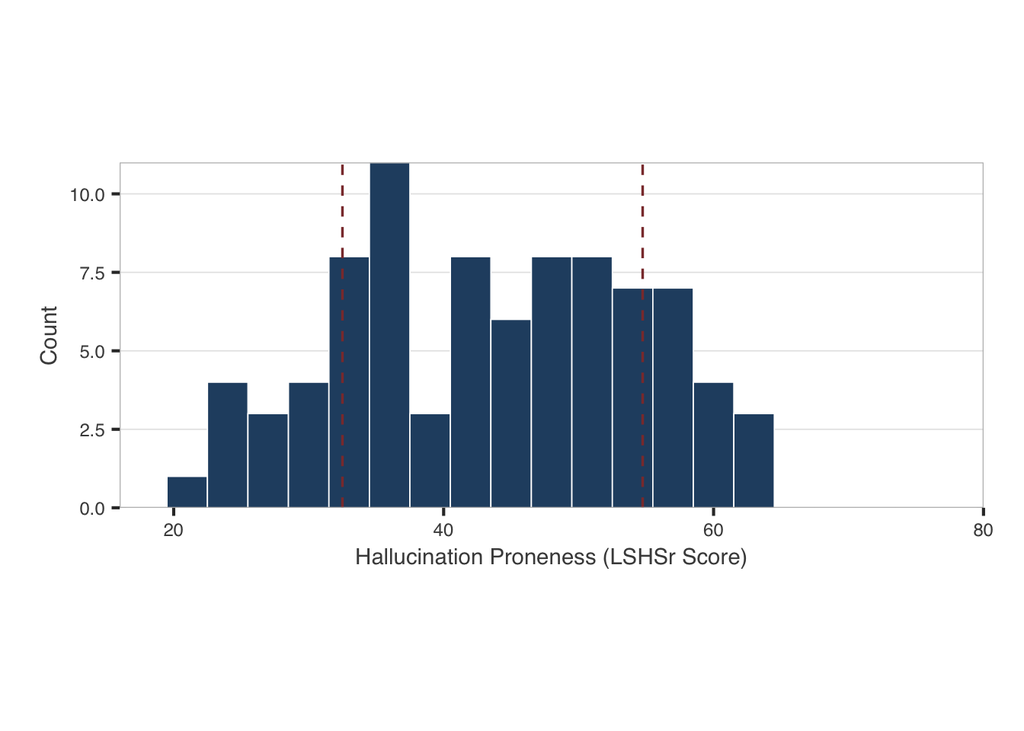

```r
lshs_m = mean(desc$lshs)
lshs_sd = sd(desc$lshs)

p_lshs = ggplot(desc, aes(x = lshs)) +
  geom_histogram(binwidth = 3, fill = "#264E70", colour = "white", linewidth = 0.3) +
  geom_vline(xintercept = lshs_m - lshs_sd, linetype = "dashed", colour = "#8B3A3A", linewidth = 0.6) +
  geom_vline(xintercept = lshs_m + lshs_sd, linetype = "dashed", colour = "#8B3A3A", linewidth = 0.6) +
  scale_x_continuous(expand = c(0, 0), limits = c(16, 80)) +
  scale_y_continuous(expand = c(0, 0)) +
  labs(x = "Hallucination Proneness (LSHSr Score)", y = "Count") +
  theme_paper(aspect_ratio = 0.4) +
  theme(plot.margin = margin(2, 20, 2, 20), legend.position = "none")
print(p_lshs)
```

# 3. Custom brms functions

```r
# creates a formatted fixed-effect table with BF10 and evidence stars for H0 and H1
# *** = BF10 < 1/100 or > 100; ** = < 1/10 or > 10; * = < 1/3 or > 3
format_bf = function(bf) {
  ifelse(is.na(bf), NA_character_,
         ifelse(is.infinite(bf), "Inf",
                ifelse(bf >= 100 | (bf > 0 & bf < 0.01),
                       formatC(bf, format = "e", digits = 2),
                       sprintf("%.2f", bf))))
}

report_bmm_fixef = function(model, caption = NULL) {
  estimates = fixef(model) %>% as.data.frame() %>% rownames_to_column("term") %>% dplyr::select(term, Estimate, Est.Error, Q2.5, Q97.5)

  terms = estimates$term
  bf_results = data.frame(term = character(), BF10 = character(), H0 = character(), H1 = character())

  for (term in terms) {
    hyp = hypothesis(model, paste(term, "= 0"))
    # the point-null hypothesis gives BF01, so invert it for BF10
    BF10_raw = abs(1 / hyp$hypothesis$Evid.Ratio)
    H0_ind = ifelse(BF10_raw < (1/100), "***", ifelse(BF10_raw < (1/10), "**", ifelse(BF10_raw < (1/3), "* ", "")))
    H1_ind = ifelse(BF10_raw > 100, "***", ifelse(BF10_raw > 10, "**", ifelse(BF10_raw > 3, "* ", "")))

    bf_results = rbind(bf_results, data.frame(term = term, BF10 = format_bf(BF10_raw), H0 = H0_ind, H1 = H1_ind))
  }

  final_table = estimates %>% left_join(bf_results, by = "term") %>% rename("2.5%" = Q2.5, "97.5%" = Q97.5)
  return(kable(final_table, digits = 2, caption = caption, escape = TRUE) %>% kable_classic("hover", full_width = FALSE, html_font = "Arial", position = "left"))
}

# extracts the same fixed effects and BF10 values as a data frame for saving as csv
# BF10_raw stays numeric for later analysis, while BF10 is formatted for display
extract_bmm_fixef = function(model) {
  estimates = fixef(model) %>% as.data.frame() %>% rownames_to_column("term") %>% dplyr::select(term, Estimate, Est.Error, Q2.5, Q97.5)

  terms = estimates$term
  bf_results = data.frame(term = character(), BF10_raw = numeric(), BF10 = character(), stringsAsFactors = FALSE)

  for (term in terms) {
    hyp = hypothesis(model, paste(term, "= 0"))
    # the point-null hypothesis gives BF01, so invert it for BF10
    BF10_raw = abs(1 / hyp$hypothesis$Evid.Ratio)
    bf_results = rbind(bf_results, data.frame(term = term, BF10_raw = BF10_raw, BF10 = format_bf(BF10_raw), stringsAsFactors = FALSE))
  }

  estimates %>% left_join(bf_results, by = "term") %>% rename("2.5%" = Q2.5, "97.5%" = Q97.5)
}

# checks the worst Rhat, bulk ESS and tail ESS across all parameters, plus total divergences
# if the model fails, the error identifies every failed threshold and its actual value
check_brms_diagnostics = function(model, label) {
  draw_summary = posterior::summarise_draws(posterior::as_draws_array(model))
  max_rhat = max(draw_summary$rhat, na.rm = TRUE)
  min_bulk_ess = min(draw_summary$ess_bulk, na.rm = TRUE)
  min_tail_ess = min(draw_summary$ess_tail, na.rm = TRUE)
  max_rhat_parameter = draw_summary$variable[which.max(draw_summary$rhat)]
  min_bulk_ess_parameter = draw_summary$variable[which.min(draw_summary$ess_bulk)]
  min_tail_ess_parameter = draw_summary$variable[which.min(draw_summary$ess_tail)]
  sampler_diagnostics = brms::nuts_params(model)
  divergences = sum(sampler_diagnostics$Parameter == "divergent__" & sampler_diagnostics$Value == 1)

  problems = character()
  if (max_rhat > 1.01) problems = c(problems, sprintf("max Rhat = %.3f for %s (> 1.01)", max_rhat, max_rhat_parameter))
  if (min_bulk_ess < 400) problems = c(problems, sprintf("min bulk ESS = %.0f for %s (< 400)", min_bulk_ess, min_bulk_ess_parameter))
  if (min_tail_ess < 400) problems = c(problems, sprintf("min tail ESS = %.0f for %s (< 400)", min_tail_ess, min_tail_ess_parameter))
  if (divergences > 0) problems = c(problems, sprintf("divergences = %d (> 0)", divergences))

  if (length(problems) > 0) stop(sprintf("%s did not pass diagnostics: %s", label, paste(problems, collapse = "; ")), call. = FALSE)
  cat(sprintf("%s passed diagnostics: max Rhat = %.3f; min bulk ESS = %.0f; min tail ESS = %.0f; divergences = %d\n", label, max_rhat, min_bulk_ess, min_tail_ess, divergences))
}

# reverses the direction of an estimate and swaps its lower and upper interval bounds
# this is for flipping the signal for the criterion measure which in brms framework is more like
# 'willingness' so needs to be flipped to create 'criterion'
signflip = function(df, cols = c("emmean", "lower.HPD", "upper.HPD")) {
  df[cols] = df[cols] * -1
  # multiplying by -1 reverses the interval, so put the bounds back in order
  temp = df[[cols[2]]]
  df[[cols[2]]] = df[[cols[3]]]
  df[[cols[3]]] = temp
  df
}

# Pairwise perturbation contrasts (custom contrast matrix)
# Grid order with at = list(bl = bl_levels, ft = ft_levels):
#   Row 1: bl=min, ft=min -> Art. Suppression (reference)
#   Row 2: bl=max, ft=min -> None (Baseline)
#   Row 3: bl=min, ft=max -> Foot-Tapping
#   Row 4: bl=max, ft=max -> impossible (weight = 0 in all contrasts)
int_contrasts = list(
  "FT - AS" = c(-1, 0, 1, 0),
  "None - AS" = c(-1, 1, 0, 0),
  "FT - None" = c(0, -1, 1, 0)
)
```

# 4. Variable Coding

**Design**: 2 (self-voice vs distorted) x 3 (none / foot-tapping / articulatory suppression) x continuous hallucination proneness.

- **signal**: deviation-coded (+/-0.5), positive = signal present
- **selfvoice**: deviation-coded (+/-0.5), positive = self-voice
- **bl**: deviation-coded dummy, positive = baseline (no interference) condition
- **ft**: deviation-coded dummy, positive = foot-tapping condition
- **lshs**: z-scored / 2 (mean=0, SD=0.5) Dividing by 2 puts continuous predictors on the same scale as deviation-coded factors.

```r
d.SDT = d %>%
  dplyr::select(SubjID, speech, interference, volume, binary_resp, lshs_score) %>%
  mutate(
    signal = scale(ifelse(volume > 0, 1, 0), scale = FALSE),
    selfvoice = scale(ifelse(speech == "self", 1, 0), scale = FALSE),
    bl = scale(ifelse(interference == "none", 1, 0), scale = FALSE),
    ft = scale(ifelse(interference == "foot-tap", 1, 0), scale = FALSE),
    lshs = scale(lshs_score)/2
  ) %>%
  rename(resp = binary_resp)

cat(sprintf("SDT dataset: %d trials from %d participants\n",
            nrow(d.SDT), length(unique(d.SDT$SubjID))))
```

```
## SDT dataset: 40800 trials from 85 participants
```

```r
sv_levels = sort(unique(round(as.numeric(d.SDT$selfvoice), 4)))
bl_levels = sort(unique(round(as.numeric(d.SDT$bl), 4)))
ft_levels = sort(unique(round(as.numeric(d.SDT$ft), 4)))

cat(sprintf("selfvoice levels: %s\n", paste(sv_levels, collapse = ", ")))
```

```
## selfvoice levels: -0.5, 0.5
```

```r
cat(sprintf("bl levels: %s\n", paste(bl_levels, collapse = ", ")))
```

```
## bl levels: -0.3333, 0.6667
```

```r
cat(sprintf("ft levels: %s\n", paste(ft_levels, collapse = ", ")))
```

```
## ft levels: -0.3333, 0.6667
```

```r
# HGF trait parameters one row per participant x condition
# HGF trait parameters analysed here: prior_posterior_weight and xprob.initial_precision
hgf_para = read.csv("model_outputs/computational_modelling_hgf/experiment_2/parameter_estimates_df.csv") %>%
  rename(SubjID = subject_nr) %>%
  mutate(
    speech = ifelse(condition < 4, "self", "distorted"),
    interference = ifelse(condition == 1 | condition == 4, "none",
                          ifelse(condition == 2 | condition == 5, "foot-tap",
                                 "whisper 'Thursday'"))
  )

d.lshs = d %>%
  group_by(SubjID) %>%
  summarise(lshs = unique(lshs_score), .groups = "drop")

hgf_para = merge(hgf_para, d.lshs, by = "SubjID")

d.hgf.session = hgf_para %>%
  mutate(
    SubjID = as.factor(SubjID),
    selfvoice = scale(ifelse(speech == "self", 1, 0), scale = FALSE),
    bl = scale(ifelse(interference == "none", 1, 0), scale = FALSE),
    ft = scale(ifelse(interference == "foot-tap", 1, 0), scale = FALSE),
    lshs = scale(lshs)/2,
    zPPW = scale(prior_posterior_weight),
    zxIP = scale(xprob__initial_precision)
  )

rm(hgf_para, d.lshs)

cat(sprintf("HGF trait dataset: %d rows (participant x condition)\n", nrow(d.hgf.session)))
```

```
## HGF trait dataset: 510 rows (participant x condition)
```

```r
# HGF state parameters, i.e. trial-by-trial trajectories recovered by replaying
# observed responses. Experiment 2 has no conditioning phase, so timestep 0 is
# the model-defined initial signal expectation used on task trial 1.
hgf_traj = read.csv("model_outputs/computational_modelling_hgf/experiment_2/estimated_state_trajectories.csv") %>%
  mutate(trialID = timestep + 1) %>%
  rename(SubjID = subject_nr) %>%
  mutate(
    speech = ifelse(condition < 4, "self", "distorted"),
    interference = ifelse(condition == 1 | condition == 4, "none",
                          ifelse(condition == 2 | condition == 5, "foot-tap",
                                 "whisper 'Thursday'"))
  )

d.hgf.trial = merge(d, hgf_traj, by = c("SubjID", "speech", "interference", "trialID")) %>%
  arrange(SubjID, speech, interference, trialID) %>%
  mutate(
    SubjID = as.factor(SubjID),
    selfvoice = scale(ifelse(speech == "self", 1, 0), scale = FALSE),
    bl = scale(ifelse(interference == "none", 1, 0), scale = FALSE),
    ft = scale(ifelse(interference == "foot-tap", 1, 0), scale = FALSE),
    lshs = scale(lshs_score)/2,
    # signal_expectation is the belief used before the current response; its logit is the same-row xprob posterior
    zmu_xprob = scale(qlogis(signal_expectation)),
    ztrialID = scale(trialID)
  )

rm(hgf_traj)

cat(sprintf("HGF state dataset: %d trial-level rows\n", nrow(d.hgf.trial)))
```

```
## HGF state dataset: 40800 trial-level rows
```

# 6. Priors

**SDT priors** (probit link): Intercept ~ N(-0.67, 0.38), b ~ N(0, 0.5), sd ~ t(3, 0, 0.5).

Identical to Exp 1 for cross-experiment comparability.

**HGF priors** (gaussian/skew_normal, z-scored DVs): Intercept ~ N(0, 1), b ~ N(0, 1), sd ~ t(3, 0, 1). Sigma and alpha use brms defaults.

```r
priors_SDT = c(
  set_prior("normal(-0.67, 0.38)", class = "Intercept"),
  set_prior("normal(0, 0.5)", class = "b"),
  set_prior("student_t(3, 0, 0.5)", class = "sd")
)

priors_hgf = c(
  set_prior("normal(0, 1)", class = "Intercept"),
  set_prior("normal(0, 1)", class = "b"),
  set_prior("student_t(3, 0, 1)", class = "sd")
)
```

# 7. Model 1: Signal Detection Theory (d’ and c)

The primary SDT model. Decomposes detection into sensitivity (d’) and criterion (c) via probit SDT parameterisation.

Formula: `signal * selfvoice * bl * lshs + signal * selfvoice * ft * lshs`

## 7.1 Model specification + load

```r
bmm.sdt = brm(
  formula = bf(resp ~ signal * selfvoice * bl * lshs +
                 signal * selfvoice * ft * lshs +
                 (0 + signal + selfvoice + bl + ft || SubjID)),
  data = d.SDT,
  family = bernoulli("probit"),
  prior = priors_SDT,
  sample_prior = TRUE,
  seed = 666,
  chains = 4,
  cores = 4,
  backend = "cmdstanr"
)
saveRDS(bmm.sdt, "model_outputs/statistical_modelling_brms/experiment_2/sdt.rds")
```

```r
bmm.sdt = readRDS("model_outputs/statistical_modelling_brms/experiment_2/sdt.rds")
# check_brms_diagnostics(bmm.sdt, "SDT") b_signal Rhat just slightly over 1.01, I will let it pass.
report_bmm_fixef(bmm.sdt, caption = "SDT Model: Fixed Effects (bernoulli/probit, all trials)")
```

SDT Model: Fixed Effects (bernoulli/probit, all trials)

term

Estimate

Est.Error

2.5%

97.5%

BF10

H0

H1

Intercept

-0.21

0.01

-0.22

-0.19

NA

NA

NA

signal

1.14

0.07

1.00

1.27

6.55e+16

***

selfvoice

-0.01

0.06

-0.13

0.12

0.12

bl

0.25

0.04

0.17

0.33

Inf

***

lshs

-0.05

0.01

-0.08

-0.02

5.27e+02

***

ft

0.09

0.03

0.03

0.15

3.56

signal:selfvoice

0.06

0.03

0.00

0.11

0.34

signal:bl

-0.04

0.03

-0.10

0.03

0.12

selfvoice:bl

-0.10

0.03

-0.17

-0.03

4.26

signal:lshs

0.02

0.13

-0.24

0.28

0.27

selfvoice:lshs

-0.09

0.12

-0.33

0.14

0.30

bl:lshs

0.17

0.08

0.00

0.33

1.17

signal:ft

0.01

0.03

-0.06

0.08

0.07

selfvoice:ft

0.00

0.03

-0.07

0.06

0.07

lshs:ft

0.07

0.06

-0.05

0.19

0.24

signal:selfvoice:bl

-0.05

0.07

-0.19

0.08

0.18

signal:selfvoice:lshs

0.47

0.06

0.35

0.58

4.37e+16

***

signal:bl:lshs

0.06

0.07

-0.08

0.19

0.19

selfvoice:bl:lshs

0.15

0.07

0.02

0.29

1.65

signal:selfvoice:ft

0.11

0.07

-0.03

0.25

0.48

signal:lshs:ft

-0.05

0.07

-0.19

0.09

0.18

selfvoice:lshs:ft

-0.01

0.07

-0.14

0.13

0.13

signal:selfvoice:bl:lshs

-0.46

0.14

-0.73

-0.18

53.01

signal:selfvoice:lshs:ft

-0.34

0.14

-0.62

-0.05

3.25

```r
write.csv(extract_bmm_fixef(bmm.sdt), "results/tables/exp2_fixef_sdt.csv", row.names = FALSE)
```

## 7.2 Posterior Predictive Check

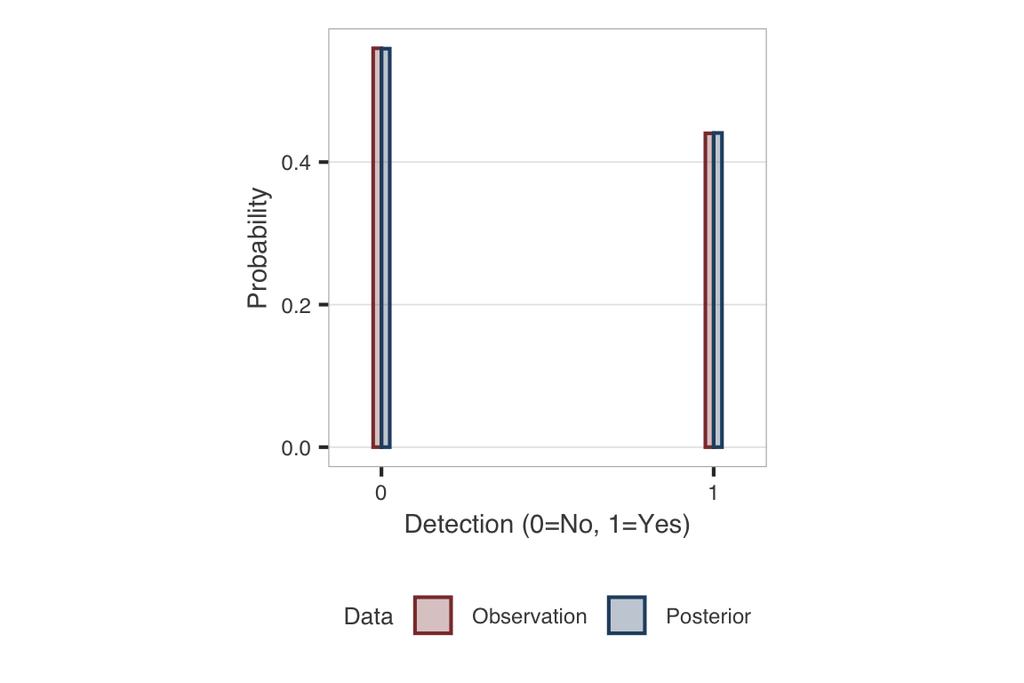

```r
set.seed(666)
posterior_predictions = posterior_predict(bmm.sdt, ndraws = 500)
posterior_check = data.frame(
  Measure = c(bmm.sdt$data$resp, as.vector(posterior_predictions)),
  Source = c(rep("Observation", nrow(bmm.sdt$data)),
             rep("Posterior", length(posterior_predictions)))
)
rm(posterior_predictions)

ggplot(posterior_check, aes(x = Measure, colour = Source, fill = Source)) +
  geom_bar(aes(y = after_stat(prop)), position = "dodge", stat = "count",
           alpha = 0.3, width = 0.05) +
  labs(x = "Detection (0=No, 1=Yes)", y = "Probability",
       colour = "Data", fill = "Data") +
  scale_colour_manual(values = c("Observation" = "#8B3A3A", "Posterior" = "#264E70")) +
  scale_fill_manual(values = c("Observation" = "#8B3A3A", "Posterior" = "#264E70")) +
  scale_x_continuous(limits = c(-0.1, 1.1), breaks = c(0, 1)) +
  theme_paper()
```

## 7.3 Sensitivity (d’)

In probit SDT with deviation-coded signal (+/-0.5), the signal slope at each condition cell equals d’ at that cell. Emtrends on `signal` gives these slopes directly.

### Signal slopes (d’) at each cell

```r
ef_dprime = emtrends(bmm.sdt, ~ selfvoice * bl * ft * lshs, var = "signal",
                      at = list(selfvoice = sv_levels, bl = bl_levels,
                                ft = ft_levels, lshs = c(-0.5, 0.5))) %>%
  as.data.frame() %>%
  filter(!(bl == max(bl_levels) & ft == max(ft_levels))) %>%
  mutate(
    selfvoice = factor(ifelse(selfvoice > 0, "Self-Voice", "Distorted"),
                       levels = c("Distorted", "Self-Voice")),
    Perturbation = factor(case_when(
      bl == max(bl_levels) ~ "None",
      ft == max(ft_levels) ~ "Foot-Tapping",
      TRUE ~ "Art. Suppression"),
      levels = c("None", "Foot-Tapping", "Art. Suppression")),
    Hallucination_Proneness = factor(ifelse(lshs < 0, "Lower Proneness (-1SD)", "Higher Proneness (+1SD)"),
                                     levels = c("Lower Proneness (-1SD)", "Higher Proneness (+1SD)"))
  ) %>%
  arrange(desc(Hallucination_Proneness), Perturbation, selfvoice)

ef_dprime %>%
  dplyr::select(selfvoice, Perturbation, Hallucination_Proneness, signal.trend, lower.HPD, upper.HPD) %>%
  kbl(digits = 2, col.names = c("Self-Voice", "Perturbation", "Hallucination Proneness",
                                 "d' (signal slope)", "Lower HPD", "Upper HPD"),
      caption = "Estimated d' by Self-Voice x Perturbation x Hallucination Proneness") %>%
  kable_styling(bootstrap_options = c("striped", "hover", "condensed"), full_width = FALSE) %>%
  row_spec(0, bold = TRUE)
```

Estimated d’ by Self-Voice x Perturbation x Hallucination Proneness

| Self-Voice | Perturbation | Hallucination Proneness | d’ (signal slope) | Lower HPD | Upper HPD |
| --- | --- | --- | --- | --- | --- |
| Distorted | None | Higher Proneness (+1SD) | 1.09 | 0.88 | 1.29 |
| Self-Voice | None | Higher Proneness (+1SD) | 1.21 | 1.01 | 1.42 |
| Distorted | Foot-Tapping | Higher Proneness (+1SD) | 0.97 | 0.76 | 1.17 |
| Self-Voice | Foot-Tapping | Higher Proneness (+1SD) | 1.32 | 1.10 | 1.52 |
| Distorted | Art. Suppression | Higher Proneness (+1SD) | 0.95 | 0.74 | 1.16 |
| Self-Voice | Art. Suppression | Higher Proneness (+1SD) | 1.36 | 1.14 | 1.58 |
| Distorted | None | Lower Proneness (-1SD) | 1.16 | 0.97 | 1.37 |
| Self-Voice | None | Lower Proneness (-1SD) | 1.00 | 0.79 | 1.19 |
| Distorted | Foot-Tapping | Lower Proneness (-1SD) | 1.20 | 1.00 | 1.42 |
| Self-Voice | Foot-Tapping | Lower Proneness (-1SD) | 1.15 | 0.94 | 1.35 |
| Distorted | Art. Suppression | Lower Proneness (-1SD) | 1.30 | 1.10 | 1.51 |
| Self-Voice | Art. Suppression | Lower Proneness (-1SD) | 0.97 | 0.77 | 1.18 |

```r
write.csv(ef_dprime, "results/tables/exp2_emmeans_dprime_3way.csv", row.names = FALSE)
```

```r
dprime_voice_pw = emtrends(bmm.sdt, ~ selfvoice | bl * ft * lshs, var = "signal",
                           at = list(selfvoice = sv_levels, bl = bl_levels,
                                     ft = ft_levels, lshs = c(-0.5, 0.5))) %>%
  contrast(method = list("Self-Voice - Distorted" = c(-1, 1))) %>%
  as.data.frame() %>%
  filter(!(bl == max(bl_levels) & ft == max(ft_levels))) %>%
  mutate(Perturbation = factor(case_when(
           bl == max(bl_levels) ~ "None",
           ft == max(ft_levels) ~ "Foot-Tapping",
           TRUE ~ "Art. Suppression"),
         levels = c("None", "Foot-Tapping", "Art. Suppression")),
         Hallucination_Proneness = factor(ifelse(lshs < 0, "Lower Proneness (-1SD)", "Higher Proneness (+1SD)"),
                                          levels = c("Lower Proneness (-1SD)", "Higher Proneness (+1SD)"))) %>%
  dplyr::select(Perturbation, Hallucination_Proneness, contrast, estimate, lower.HPD, upper.HPD)

write.csv(dprime_voice_pw, "results/tables/exp2_contrasts_dprime_articulatory_prior_by_perturbation_x_hallucination_proneness.csv", row.names = FALSE)
```

```r
dprime_proneness_pw = emtrends(bmm.sdt, ~ lshs | selfvoice * bl * ft, var = "signal",
                               at = list(selfvoice = sv_levels, bl = bl_levels,
                                         ft = ft_levels, lshs = c(-0.5, 0.5))) %>%
  contrast(method = list("Higher - Lower Proneness" = c(-1, 1))) %>%
  as.data.frame() %>%
  filter(!(bl == max(bl_levels) & ft == max(ft_levels))) %>%
  mutate(
    Self_Voice = factor(ifelse(selfvoice > 0, "Self-Voice", "Distorted"),
                        levels = c("Distorted", "Self-Voice")),
    Perturbation = factor(case_when(
      bl == max(bl_levels) ~ "None",
      ft == max(ft_levels) ~ "Foot-Tapping",
      TRUE ~ "Art. Suppression"),
      levels = c("None", "Foot-Tapping", "Art. Suppression"))
  ) %>%
  dplyr::select(Self_Voice, Perturbation, contrast, estimate, lower.HPD, upper.HPD)

write.csv(dprime_proneness_pw,
          "results/tables/exp2_contrasts_dprime_hallucination_proneness_by_articulatory_prior_x_perturbation.csv",
          row.names = FALSE)
```

### Signal Slopes: Articulatory Prior x Hallucination Proneness

```r
ef_dprime_sv_lshs = emtrends(bmm.sdt, ~ selfvoice * lshs, var = "signal",
                               at = list(selfvoice = sv_levels,
                                         lshs = c(-0.5, 0.5))) %>%
  as.data.frame() %>%
  mutate(
    selfvoice = factor(ifelse(selfvoice > 0, "Self-Voice", "Distorted"),
                       levels = c("Distorted", "Self-Voice")),
    Hallucination_Proneness = factor(ifelse(lshs < 0, "Lower Proneness (-1SD)", "Higher Proneness (+1SD)"),
                                     levels = c("Lower Proneness (-1SD)", "Higher Proneness (+1SD)"))
  )

ef_dprime_sv_lshs %>%
  dplyr::select(selfvoice, Hallucination_Proneness, signal.trend, lower.HPD, upper.HPD) %>%
  kbl(digits = 2,
      col.names = c("Self-Voice", "Hallucination Proneness", "d' (signal slope)", "Lower HPD", "Upper HPD"),
      caption = "Estimated d' by Articulatory Prior x Hallucination Proneness (collapsed over perturbation)") %>%
  kable_styling(bootstrap_options = c("striped", "hover", "condensed"), full_width = FALSE) %>%
  row_spec(0, bold = TRUE)
```

Estimated d’ by Articulatory Prior x Hallucination Proneness (collapsed over perturbation)

| Self-Voice | Hallucination Proneness | d’ (signal slope) | Lower HPD | Upper HPD |
| --- | --- | --- | --- | --- |
| Distorted | Lower Proneness (-1SD) | 1.18 | 0.99 | 1.37 |
| Self-Voice | Lower Proneness (-1SD) | 1.07 | 0.89 | 1.27 |
| Distorted | Higher Proneness (+1SD) | 1.03 | 0.83 | 1.22 |
| Self-Voice | Higher Proneness (+1SD) | 1.26 | 1.07 | 1.47 |

```r
write.csv(ef_dprime_sv_lshs, "results/tables/exp2_emmeans_dprime_svxlshs.csv", row.names = FALSE)
```

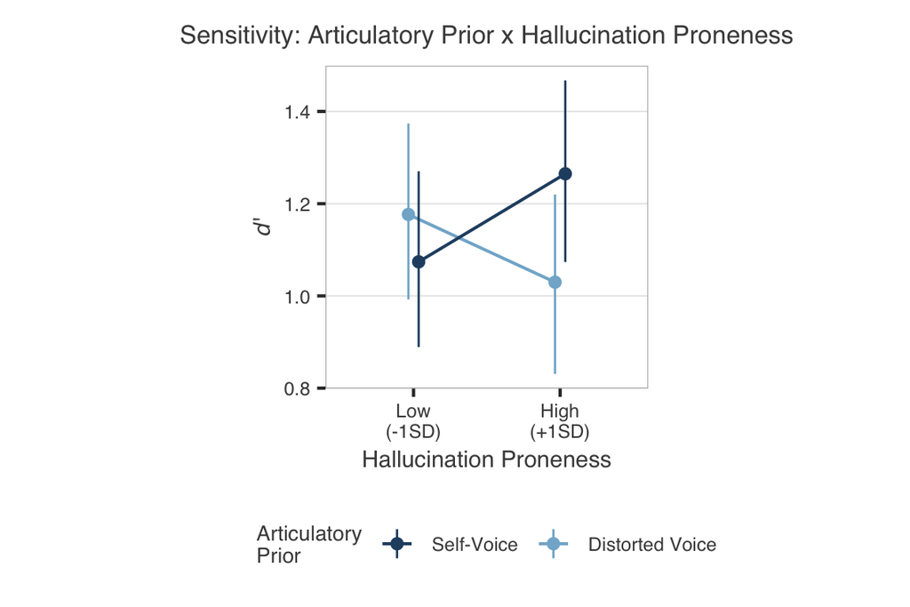

```r
distorted_dprime_2way = ef_dprime_sv_lshs %>% filter(selfvoice == "Distorted")
selfvoice_dprime_2way = ef_dprime_sv_lshs %>% filter(selfvoice == "Self-Voice")
distorted_position = position_nudge(x = -0.035)
selfvoice_position = position_nudge(x = 0.035)

fig_dprime_sv_lshs = ggplot(ef_dprime_sv_lshs, aes(x = Hallucination_Proneness, y = signal.trend, colour = selfvoice)) +
  geom_line(data = distorted_dprime_2way, aes(group = selfvoice), linewidth = 0.7, position = distorted_position) +
  geom_linerange(data = distorted_dprime_2way, aes(ymin = lower.HPD, ymax = upper.HPD), linewidth = 0.5, position = distorted_position) +
  geom_point(data = distorted_dprime_2way, size = 2, position = distorted_position) +
  geom_line(data = selfvoice_dprime_2way, aes(group = selfvoice), linewidth = 0.7, position = selfvoice_position) +
  geom_linerange(data = selfvoice_dprime_2way, aes(ymin = lower.HPD, ymax = upper.HPD), linewidth = 0.5, position = selfvoice_position) +
  geom_point(data = selfvoice_dprime_2way, size = 2, position = selfvoice_position) +
  scale_colour_manual(values = c("Distorted" = "#82B3D1", "Self-Voice" = "#264E70"), limits = c("Self-Voice", "Distorted"), labels = c("Self-Voice", "Distorted Voice")) +
  scale_x_discrete(labels = c("Lower Proneness (-1SD)" = "Low\n(-1SD)", "Higher Proneness (+1SD)" = "High\n(+1SD)")) +
  theme_paper() +
  labs(title = "Sensitivity: Articulatory Prior x Hallucination Proneness",
       x = "Hallucination Proneness", y = expression(italic(d)*"'"), colour = "Articulatory\nPrior")

print(fig_dprime_sv_lshs)
```

```r
dprime_int_pw = emtrends(bmm.sdt, ~ bl * ft | selfvoice * lshs, var = "signal",
                           at = list(selfvoice = sv_levels, bl = bl_levels,
                                     ft = ft_levels, lshs = c(-0.5, 0.5))) %>%
  contrast(int_contrasts) %>%
  as.data.frame() %>%
  mutate(
    Self_Voice = factor(ifelse(selfvoice > 0, "Self-Voice", "Distorted"),
                        levels = c("Distorted", "Self-Voice")),
    Hallucination_Proneness = factor(ifelse(lshs < 0, "Lower Proneness (-1SD)", "Higher Proneness (+1SD)"),
                                     levels = c("Lower Proneness (-1SD)", "Higher Proneness (+1SD)"))
  ) %>%
  dplyr::select(Self_Voice, Hallucination_Proneness, contrast, estimate, lower.HPD, upper.HPD)

dprime_int_pw %>%
  kbl(digits = 3,
      col.names = c("Self-Voice", "Hallucination Proneness", "Contrast", "Estimate",
                     "Lower HPD", "Upper HPD"),
      caption = "d': Pairwise Perturbation Contrasts at Each Articulatory Prior x Hallucination Proneness Cell") %>%
  kable_styling(bootstrap_options = c("striped", "hover", "condensed"), full_width = FALSE) %>%
  row_spec(0, bold = TRUE)
```

d’: Pairwise Perturbation Contrasts at Each Articulatory Prior x Hallucination Proneness Cell

| Self-Voice | Hallucination Proneness | Contrast | Estimate | Lower HPD | Upper HPD |
| --- | --- | --- | --- | --- | --- |
| Distorted | Lower Proneness (-1SD) | FT - AS | -0.102 | -0.246 | 0.034 |
| Distorted | Lower Proneness (-1SD) | None - AS | -0.152 | -0.297 | -0.026 |
| Distorted | Lower Proneness (-1SD) | FT - None | 0.048 | -0.088 | 0.175 |
| Self-Voice | Lower Proneness (-1SD) | FT - AS | 0.179 | 0.036 | 0.319 |
| Self-Voice | Lower Proneness (-1SD) | None - AS | 0.024 | -0.113 | 0.159 |
| Self-Voice | Lower Proneness (-1SD) | FT - None | 0.153 | 0.022 | 0.291 |
| Distorted | Higher Proneness (+1SD) | FT - AS | 0.017 | -0.117 | 0.153 |
| Distorted | Higher Proneness (+1SD) | None - AS | 0.134 | 0.004 | 0.271 |
| Distorted | Higher Proneness (+1SD) | FT - None | -0.118 | -0.255 | 0.011 |
| Self-Voice | Higher Proneness (+1SD) | FT - AS | -0.040 | -0.199 | 0.088 |
| Self-Voice | Higher Proneness (+1SD) | None - AS | -0.151 | -0.291 | -0.003 |
| Self-Voice | Higher Proneness (+1SD) | FT - None | 0.110 | -0.034 | 0.255 |

```r
write.csv(dprime_int_pw, "results/tables/exp2_contrasts_dprime_perturbation.csv", row.names = FALSE)
```

### Figure: Sensitivity by Articulatory Prior x Perturbation x Hallucination Proneness

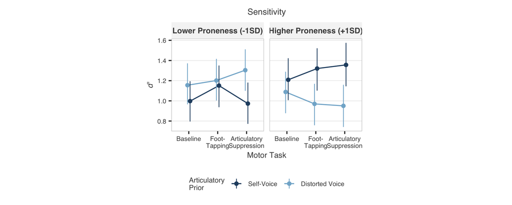

```r
p_dprime_hl = ggplot(ef_dprime, aes(x = Perturbation, y = signal.trend,
                                    colour = selfvoice, group = selfvoice)) +
  geom_line(linewidth = 0.7, position = voice_position) +
  geom_linerange(aes(ymin = lower.HPD, ymax = upper.HPD), linewidth = 0.5,
                 position = voice_position) +
  geom_point(size = 2, position = voice_position) +
  facet_wrap(~ Hallucination_Proneness, nrow = 1) +
  scale_colour_manual(values = c("Distorted" = "#82B3D1", "Self-Voice" = "#264E70"), limits = c("Self-Voice", "Distorted"), labels = c("Self-Voice", "Distorted Voice")) +
  scale_x_discrete(labels = c("None" = "Baseline", "Foot-Tapping" = "Foot-\nTapping",
                              "Art. Suppression" = "Articulatory\nSuppression")) +
  theme_paper() +
  labs(title = "Sensitivity", x = "Motor Task", y = expression(italic(d)*"'"),
       colour = "Articulatory\nPrior")

print(p_dprime_hl)
```

# 8. HGF Trait Parameters (Session-Level)

Per-participant posterior medians of prior-posterior weight and xprob initial precision.

Family: gaussian | Formula: `zDV ~ selfvoice * bl * lshs + selfvoice * ft * lshs + (1 + selfvoice + bl + ft || SubjID)`

## 8.1 Model specification + load

```r
bmm.hgf.ppw = brm(zPPW ~ selfvoice * bl * lshs + selfvoice * ft * lshs +
                      (1 + selfvoice + bl + ft || SubjID),
                    data = d.hgf.session, family = gaussian(), prior = priors_hgf,
                    sample_prior = TRUE, seed = 666, chains = 4, cores = 4,
                    backend = "cmdstanr",
                    control = list(adapt_delta = 0.99))
saveRDS(bmm.hgf.ppw, "model_outputs/statistical_modelling_brms/experiment_2/hgf_prior_posterior_weight.rds")

bmm.hgf.xip = brm(zxIP ~ selfvoice * bl * lshs + selfvoice * ft * lshs +
                      (1 + selfvoice + bl + ft || SubjID),
                     data = d.hgf.session, family = gaussian(), prior = priors_hgf,
                     sample_prior = TRUE, seed = 666, chains = 4, cores = 4,
                     backend = "cmdstanr",
                     control = list(adapt_delta = 0.99))
saveRDS(bmm.hgf.xip, "model_outputs/statistical_modelling_brms/experiment_2/hgf_initial_precision.rds")
```

```r
bmm.hgf.ppw = readRDS("model_outputs/statistical_modelling_brms/experiment_2/hgf_prior_posterior_weight.rds")
bmm.hgf.xip = readRDS("model_outputs/statistical_modelling_brms/experiment_2/hgf_initial_precision.rds")

check_brms_diagnostics(bmm.hgf.ppw, "HGF prior-posterior weight")
```

```
## HGF prior-posterior weight passed diagnostics: max Rhat = 1.005; min bulk ESS = 580; min tail ESS = 653; divergences = 0
```

```r
check_brms_diagnostics(bmm.hgf.xip, "HGF xprob initial precision")
```

```
## HGF xprob initial precision passed diagnostics: max Rhat = 1.007; min bulk ESS = 505; min tail ESS = 587; divergences = 0
```

```r
report_bmm_fixef(bmm.hgf.ppw, caption = "HGF Trait: Prior-Posterior Weight (gaussian)")
```

HGF Trait: Prior-Posterior Weight (gaussian)

term

Estimate

Est.Error

2.5%

97.5%

BF10

H0

H1

Intercept

0.00

0.07

-0.14

0.14

NA

NA

NA

selfvoice

-0.09

0.10

-0.28

0.11

0.15

bl

0.19

0.08

0.03

0.36

1.11

lshs

-0.14

0.14

-0.43

0.13

0.23

ft

0.11

0.07

-0.03

0.26

0.24

selfvoice:bl

-0.10

0.14

-0.39

0.18

0.19

selfvoice:lshs

-0.54

0.19

-0.92

-0.17

10.22

bl:lshs

0.07

0.16

-0.25

0.38

0.17

selfvoice:ft

-0.25

0.14

-0.52

0.03

0.63

lshs:ft

0.15

0.15

-0.14

0.44

0.24

selfvoice:bl:lshs

0.85

0.28

0.31

1.40

26.10

selfvoice:lshs:ft

0.14

0.27

-0.39

0.66

0.32

```r
report_bmm_fixef(bmm.hgf.xip, caption = "HGF Trait: xprob Initial Precision (gaussian)")
```

HGF Trait: xprob Initial Precision (gaussian)

term

Estimate

Est.Error

2.5%

97.5%

BF10

H0

H1

Intercept

0.00

0.05

-0.10

0.09

NA

NA

NA

selfvoice

0.04

0.10

-0.15

0.24

0.11

bl

-0.01

0.10

-0.22

0.19

0.10

lshs

0.11

0.10

-0.08

0.31

0.18

ft

0.03

0.10

-0.17

0.23

0.10

selfvoice:bl

-0.15

0.20

-0.52

0.23

0.27

selfvoice:lshs

-0.04

0.20

-0.44

0.36

0.20

bl:lshs

-0.17

0.21

-0.58

0.24

0.27

selfvoice:ft

0.12

0.20

-0.26

0.51

0.23

lshs:ft

-0.19

0.20

-0.59

0.21

0.30

selfvoice:bl:lshs

0.02

0.37

-0.72

0.77

0.37

selfvoice:lshs:ft

0.40

0.37

-0.33

1.12

0.61

```r
write.csv(extract_bmm_fixef(bmm.hgf.ppw), "results/tables/exp2_fixef_hgf_ppw.csv", row.names = FALSE)
write.csv(extract_bmm_fixef(bmm.hgf.xip), "results/tables/exp2_fixef_hgf_xip.csv", row.names = FALSE)
```

## 8.2 Prior-Posterior Weight: Articulatory Prior x Hallucination Proneness

```r
ef_ppw_sv_lshs = emmeans(bmm.hgf.ppw, ~ selfvoice * lshs,
                          at = list(selfvoice = sv_levels,
                                    lshs = c(-0.5, 0.5))) %>%
  as.data.frame() %>%
  mutate(
    selfvoice = factor(ifelse(selfvoice > 0, "Self-Voice", "Distorted"),
                       levels = c("Distorted", "Self-Voice")),
    Hallucination_Proneness = factor(ifelse(lshs < 0, "Lower Proneness (-1SD)", "Higher Proneness (+1SD)"),
                                     levels = c("Lower Proneness (-1SD)", "Higher Proneness (+1SD)"))
  )

ef_ppw_sv_lshs %>%
  dplyr::select(selfvoice, Hallucination_Proneness, emmean, lower.HPD, upper.HPD) %>%
  kbl(digits = 2,
      col.names = c("Self-Voice", "Hallucination Proneness", "PPW (z)", "Lower HPD", "Upper HPD"),
      caption = "PPW: Estimated Marginal Means by Articulatory Prior x Hallucination Proneness (collapsed over perturbation)") %>%
  kable_styling(bootstrap_options = c("striped", "hover", "condensed"), full_width = FALSE) %>%
  row_spec(0, bold = TRUE)
```

PPW: Estimated Marginal Means by Articulatory Prior x Hallucination Proneness (collapsed over perturbation)

| Self-Voice | Hallucination Proneness | PPW (z) | Lower HPD | Upper HPD |
| --- | --- | --- | --- | --- |
| Distorted | Lower Proneness (-1SD) | 0.08 | -0.16 | 0.35 |
| Self-Voice | Lower Proneness (-1SD) | 0.13 | -0.14 | 0.37 |
| Distorted | Higher Proneness (+1SD) | 0.16 | -0.07 | 0.42 |
| Self-Voice | Higher Proneness (+1SD) | -0.17 | -0.41 | 0.08 |

```r
write.csv(ef_ppw_sv_lshs, "results/tables/exp2_emmeans_ppw_svxlshs.csv", row.names = FALSE)
```

```r
ppw_sv_slopes = emtrends(bmm.hgf.ppw, ~ lshs, var = "selfvoice",
                           at = list(lshs = c(-0.5, 0.5))) %>%
  as.data.frame() %>%
  mutate(
    Hallucination_Proneness = factor(ifelse(lshs < 0, "Lower Proneness (-1SD)", "Higher Proneness (+1SD)"),
                                     levels = c("Lower Proneness (-1SD)", "Higher Proneness (+1SD)"))
  ) %>%
  dplyr::select(Hallucination_Proneness, selfvoice.trend, lower.HPD, upper.HPD)

ppw_sv_slopes %>%
  kbl(digits = 3, col.names = c("Hallucination Proneness", "Self-Voice Slope",
                                 "Lower HPD", "Upper HPD"),
      caption = "PPW: Articulatory Prior Slopes at Each Hallucination Proneness Level") %>%
  kable_styling(bootstrap_options = c("striped", "hover", "condensed"), full_width = FALSE) %>%
  row_spec(0, bold = TRUE)
```

PPW: Articulatory Prior Slopes at Each Hallucination Proneness Level

| Hallucination Proneness | Self-Voice Slope | Lower HPD | Upper HPD |
| --- | --- | --- | --- |
| Lower Proneness (-1SD) | 0.041 | -0.248 | 0.351 |
| Higher Proneness (+1SD) | -0.332 | -0.619 | -0.039 |

```r
write.csv(ppw_sv_slopes, "results/tables/exp2_slopes_ppw_articulatory_prior_by_hallucination_proneness.csv", row.names = FALSE)
```

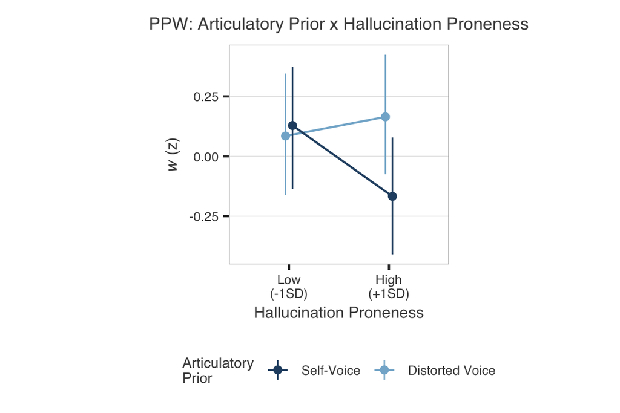

```r
distorted_ppw_2way = ef_ppw_sv_lshs %>% filter(selfvoice == "Distorted")
selfvoice_ppw_2way = ef_ppw_sv_lshs %>% filter(selfvoice == "Self-Voice")
distorted_position = position_nudge(x = -0.035)
selfvoice_position = position_nudge(x = 0.035)

fig_ppw_sv_lshs = ggplot(ef_ppw_sv_lshs, aes(x = Hallucination_Proneness, y = emmean, colour = selfvoice)) +
  geom_line(data = distorted_ppw_2way, aes(group = selfvoice), linewidth = 0.7, position = distorted_position) +
  geom_linerange(data = distorted_ppw_2way, aes(ymin = lower.HPD, ymax = upper.HPD), linewidth = 0.5, position = distorted_position) +
  geom_point(data = distorted_ppw_2way, size = 2, position = distorted_position) +
  geom_line(data = selfvoice_ppw_2way, aes(group = selfvoice), linewidth = 0.7, position = selfvoice_position) +
  geom_linerange(data = selfvoice_ppw_2way, aes(ymin = lower.HPD, ymax = upper.HPD), linewidth = 0.5, position = selfvoice_position) +
  geom_point(data = selfvoice_ppw_2way, size = 2, position = selfvoice_position) +
  scale_colour_manual(values = c("Distorted" = "#82B3D1", "Self-Voice" = "#264E70"), limits = c("Self-Voice", "Distorted"), labels = c("Self-Voice", "Distorted Voice")) +
  scale_x_discrete(labels = c("Lower Proneness (-1SD)" = "Low\n(-1SD)", "Higher Proneness (+1SD)" = "High\n(+1SD)")) +
  theme_paper() +
  labs(title = "PPW: Articulatory Prior x Hallucination Proneness",
       x = "Hallucination Proneness", y = expression(italic(w) * " (z)"), colour = "Articulatory\nPrior")

print(fig_ppw_sv_lshs)
```

## 8.3 Prior-Posterior Weight: Articulatory Prior x Perturbation x Hallucination Proneness

```r
ef_ppw = emmeans(bmm.hgf.ppw, ~ selfvoice * bl * ft * lshs,
                  at = list(selfvoice = sv_levels, bl = bl_levels,
                            ft = ft_levels, lshs = c(-0.5, 0.5))) %>%
  as.data.frame() %>%
  filter(!(bl == max(bl_levels) & ft == max(ft_levels))) %>%
  mutate(
    selfvoice = factor(ifelse(selfvoice > 0, "Self-Voice", "Distorted"),
                       levels = c("Distorted", "Self-Voice")),
    Perturbation = factor(case_when(
      bl == max(bl_levels) ~ "None",
      ft == max(ft_levels) ~ "Foot-Tapping",
      TRUE ~ "Art. Suppression"),
      levels = c("None", "Foot-Tapping", "Art. Suppression")),
    Hallucination_Proneness = factor(ifelse(lshs < 0, "Lower Proneness (-1SD)", "Higher Proneness (+1SD)"),
                                     levels = c("Lower Proneness (-1SD)", "Higher Proneness (+1SD)"))
  ) %>%
  arrange(desc(Hallucination_Proneness), Perturbation, selfvoice)

ef_ppw %>%
  dplyr::select(selfvoice, Perturbation, Hallucination_Proneness, emmean, lower.HPD, upper.HPD) %>%
  kbl(digits = 2, caption = "PPW: Estimated Marginal Means by Articulatory Prior x Perturbation x Hallucination Proneness") %>%
  kable_styling(bootstrap_options = c("striped", "hover", "condensed"), full_width = FALSE) %>%
  row_spec(0, bold = TRUE)
```

PPW: Estimated Marginal Means by Articulatory Prior x Perturbation x Hallucination Proneness

| selfvoice | Perturbation | Hallucination_Proneness | emmean | lower.HPD | upper.HPD |
| --- | --- | --- | --- | --- | --- |
| Distorted | None | Higher Proneness (+1SD) | 0.06 | -0.24 | 0.36 |
| Self-Voice | None | Higher Proneness (+1SD) | -0.03 | -0.31 | 0.27 |
| Distorted | Foot-Tapping | Higher Proneness (+1SD) | 0.27 | -0.02 | 0.57 |
| Self-Voice | Foot-Tapping | Higher Proneness (+1SD) | -0.31 | -0.60 | -0.02 |
| Distorted | Art. Suppression | Higher Proneness (+1SD) | 0.00 | -0.29 | 0.28 |
| Self-Voice | Art. Suppression | Higher Proneness (+1SD) | -0.41 | -0.69 | -0.13 |
| Distorted | None | Lower Proneness (-1SD) | 0.20 | -0.10 | 0.51 |
| Self-Voice | None | Lower Proneness (-1SD) | 0.14 | -0.17 | 0.41 |
| Distorted | Foot-Tapping | Lower Proneness (-1SD) | -0.03 | -0.31 | 0.28 |
| Self-Voice | Foot-Tapping | Lower Proneness (-1SD) | 0.12 | -0.17 | 0.43 |
| Distorted | Art. Suppression | Lower Proneness (-1SD) | -0.22 | -0.51 | 0.09 |
| Self-Voice | Art. Suppression | Lower Proneness (-1SD) | 0.24 | -0.06 | 0.54 |

```r
write.csv(ef_ppw, "results/tables/exp2_emmeans_ppw_3way.csv", row.names = FALSE)
```

```r
ppw_voice_pw = emmeans(
  bmm.hgf.ppw, ~ selfvoice | bl * ft * lshs,
  at = list(selfvoice = sv_levels, bl = bl_levels,
            ft = ft_levels, lshs = c(-0.5, 0.5))
) %>%
  contrast(method = list("Self-Voice - Distorted" = c(-1, 1))) %>%
  as.data.frame() %>%
  filter(!(bl == max(bl_levels) & ft == max(ft_levels))) %>%
  mutate(
    Perturbation = factor(case_when(
      bl == max(bl_levels) ~ "None",
      ft == max(ft_levels) ~ "Foot-Tapping",
      TRUE ~ "Art. Suppression"),
      levels = c("None", "Foot-Tapping", "Art. Suppression")),
    Hallucination_Proneness = factor(ifelse(lshs < 0, "Lower Proneness (-1SD)", "Higher Proneness (+1SD)"),
                                     levels = c("Lower Proneness (-1SD)", "Higher Proneness (+1SD)"))
  ) %>%
  dplyr::select(Perturbation, Hallucination_Proneness, contrast, estimate, lower.HPD, upper.HPD)

write.csv(ppw_voice_pw,
          "results/tables/exp2_contrasts_ppw_articulatory_prior_by_perturbation_x_hallucination_proneness.csv",
          row.names = FALSE)
```

```r
ppw_int_pw = emmeans(bmm.hgf.ppw, ~ bl * ft | selfvoice * lshs,
                       at = list(selfvoice = sv_levels, bl = bl_levels,
                                 ft = ft_levels, lshs = c(-0.5, 0.5))) %>%
  contrast(int_contrasts) %>%
  as.data.frame() %>%
  mutate(
    Self_Voice = factor(ifelse(selfvoice > 0, "Self-Voice", "Distorted"),
                        levels = c("Distorted", "Self-Voice")),
    Hallucination_Proneness = factor(ifelse(lshs < 0, "Lower Proneness (-1SD)", "Higher Proneness (+1SD)"),
                                     levels = c("Lower Proneness (-1SD)", "Higher Proneness (+1SD)"))
  ) %>%
  dplyr::select(Self_Voice, Hallucination_Proneness, contrast, estimate, lower.HPD, upper.HPD)

ppw_int_pw %>%
  kbl(digits = 3,
      col.names = c("Self-Voice", "Hallucination Proneness", "Contrast", "Estimate",
                     "Lower HPD", "Upper HPD"),
      caption = "PPW: Pairwise Perturbation Contrasts at Each Articulatory Prior x Hallucination Proneness Cell") %>%
  kable_styling(bootstrap_options = c("striped", "hover", "condensed"), full_width = FALSE) %>%
  row_spec(0, bold = TRUE)
```

PPW: Pairwise Perturbation Contrasts at Each Articulatory Prior x Hallucination Proneness Cell

| Self-Voice | Hallucination Proneness | Contrast | Estimate | Lower HPD | Upper HPD |
| --- | --- | --- | --- | --- | --- |
| Distorted | Lower Proneness (-1SD) | FT - AS | 0.193 | -0.070 | 0.479 |
| Distorted | Lower Proneness (-1SD) | None - AS | 0.423 | 0.114 | 0.708 |
| Distorted | Lower Proneness (-1SD) | FT - None | -0.228 | -0.547 | 0.052 |
| Self-Voice | Lower Proneness (-1SD) | FT - AS | -0.126 | -0.412 | 0.159 |
| Self-Voice | Lower Proneness (-1SD) | None - AS | -0.109 | -0.392 | 0.199 |
| Self-Voice | Lower Proneness (-1SD) | FT - None | -0.016 | -0.320 | 0.277 |
| Distorted | Higher Proneness (+1SD) | FT - AS | 0.274 | -0.003 | 0.546 |
| Distorted | Higher Proneness (+1SD) | None - AS | 0.060 | -0.244 | 0.354 |
| Distorted | Higher Proneness (+1SD) | FT - None | 0.209 | -0.081 | 0.517 |
| Self-Voice | Higher Proneness (+1SD) | FT - AS | 0.102 | -0.183 | 0.365 |
| Self-Voice | Higher Proneness (+1SD) | None - AS | 0.386 | 0.096 | 0.686 |
| Self-Voice | Higher Proneness (+1SD) | FT - None | -0.283 | -0.589 | 0.026 |

```r
write.csv(ppw_int_pw, "results/tables/exp2_contrasts_ppw_perturbation.csv", row.names = FALSE)
```

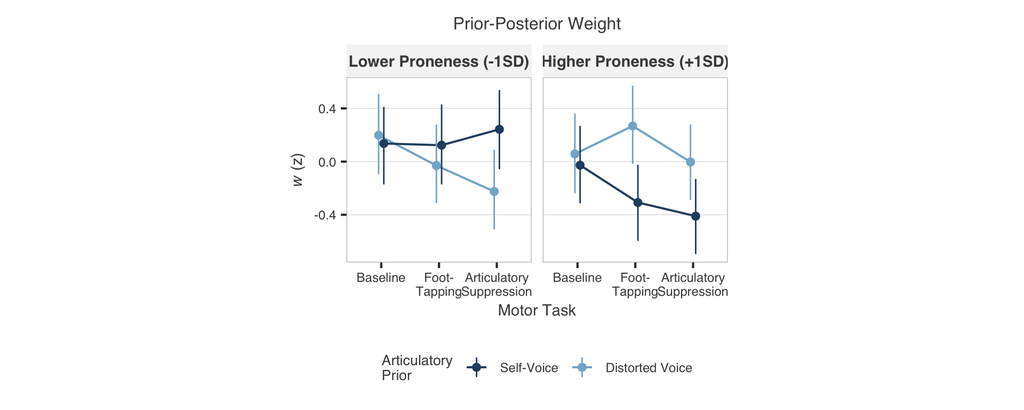

```r
p_ppw_sm = ggplot(ef_ppw, aes(x = Perturbation, y = emmean,
                              colour = selfvoice, group = selfvoice)) +
  geom_line(linewidth = 0.7, position = voice_position) +
  geom_linerange(aes(ymin = lower.HPD, ymax = upper.HPD), linewidth = 0.5,
                 position = voice_position) +
  geom_point(size = 2, position = voice_position) +
  facet_wrap(~ Hallucination_Proneness, nrow = 1) +
  scale_colour_manual(values = c("Distorted" = "#82B3D1", "Self-Voice" = "#264E70"), limits = c("Self-Voice", "Distorted"), labels = c("Self-Voice", "Distorted Voice")) +
  scale_x_discrete(labels = c("None" = "Baseline", "Foot-Tapping" = "Foot-\nTapping",
                              "Art. Suppression" = "Articulatory\nSuppression")) +
  theme_paper() +
  labs(title = "Prior-Posterior Weight", x = "Motor Task",
       y = expression(italic(w) * " (z)"), colour = "Articulatory\nPrior")

print(p_ppw_sm)
```

# 9. HGF Signal Expectation

Trial-by-trial signal-expectation estimates from the HGF model.

Family: gaussian. Data: all trials merged with HGF trajectories.

## 9.1 Model specification + load

```r
# keep 3,000 post-warm-up draws per chain for state-model convergence
bmm.hgf.xprob = brm(zmu_xprob ~ selfvoice * bl * lshs + selfvoice * ft * lshs +
                       ztrialID + (1 + selfvoice + bl + ft || SubjID),
                     data = d.hgf.trial, family = gaussian(), prior = priors_hgf,
                     sample_prior = TRUE, seed = 666, chains = 4, cores = 4,
                     iter = 4000, warmup = 1000,
                     backend = "cmdstanr")
saveRDS(bmm.hgf.xprob, "model_outputs/statistical_modelling_brms/experiment_2/hgf_signal_expectation.rds")
```

```r
bmm.hgf.xprob = readRDS("model_outputs/statistical_modelling_brms/experiment_2/hgf_signal_expectation.rds")

check_brms_diagnostics(bmm.hgf.xprob, "HGF signal expectation")
```

```
## HGF signal expectation passed diagnostics: max Rhat = 1.007; min bulk ESS = 833; min tail ESS = 1433; divergences = 0
```

```r
report_bmm_fixef(bmm.hgf.xprob, caption = "HGF State: Signal Expectation (gaussian + ztrialID)")
```

HGF State: Signal Expectation (gaussian + ztrialID)

term

Estimate

Est.Error

2.5%

97.5%

BF10

H0

H1

Intercept

0.01

0.07

-0.13

0.14

NA

NA

NA

selfvoice

0.02

0.09

-0.16

0.19

0.09

bl

0.36

0.07

0.22

0.49

9.56e+02

***

lshs

-0.04

0.14

-0.33

0.23

0.15

ft

0.16

0.04

0.07

0.25

33.89

ztrialID

-0.21

0.00

-0.22

-0.21

3.99e+14

***

selfvoice:bl

-0.13

0.01

-0.15

-0.10

Inf

***

selfvoice:lshs

-0.03

0.17

-0.37

0.30

0.17

bl:lshs

0.24

0.13

-0.02

0.50

0.66

selfvoice:ft

-0.01

0.01

-0.03

0.02

0.02

lshs:ft

0.02

0.09

-0.15

0.20

0.09

selfvoice:bl:lshs

0.10

0.02

0.05

0.15

42.65

selfvoice:lshs:ft

-0.06

0.02

-0.11

-0.01

0.71

```r
write.csv(extract_bmm_fixef(bmm.hgf.xprob), "results/tables/exp2_fixef_hgf_xprob.csv", row.names = FALSE)
```

## 9.2 Signal Expectation

### Signal Expectation: Articulatory Prior x Perturbation

```r
ef_xprob_2way = emmeans(bmm.hgf.xprob, ~ selfvoice * bl * ft,
                        at = list(selfvoice = sv_levels,
                                  bl = bl_levels, ft = ft_levels)) %>%
  as.data.frame() %>%
  filter(!(bl == max(bl_levels) & ft == max(ft_levels))) %>%
  mutate(
    selfvoice = factor(ifelse(selfvoice > 0, "Self-Voice", "Distorted"),
                       levels = c("Distorted", "Self-Voice")),
    Perturbation = factor(case_when(
      bl == max(bl_levels) ~ "None",
      ft == max(ft_levels) ~ "Foot-Tapping",
      TRUE ~ "Art. Suppression"),
      levels = c("None", "Foot-Tapping", "Art. Suppression"))
  ) %>%
  arrange(selfvoice, Perturbation)

ef_xprob_2way %>%
  dplyr::select(selfvoice, Perturbation, emmean, lower.HPD, upper.HPD) %>%
  kbl(digits = 2,
      col.names = c("Self-Voice", "Perturbation", "$\\hat{\\mu}_{xprob}$ (z)", "Lower HPD", "Upper HPD"),
      caption = "$\\hat{\\mu}_{xprob}$: Estimated Marginal Means by Articulatory Prior x Perturbation (collapsed over hallucination proneness)") %>%
  kable_styling(bootstrap_options = c("striped", "hover", "condensed"), full_width = FALSE) %>%
  row_spec(0, bold = TRUE)
```

$\hat{\mu}_{xprob}$: Estimated Marginal Means by Articulatory Prior x Perturbation (collapsed over hallucination proneness)

| Self-Voice | Perturbation | $\hat{\mu}_{xprob}$ (z) | Lower HPD | Upper HPD |
| --- | --- | --- | --- | --- |
| Distorted | None | 0.22 | 0.03 | 0.42 |
| Distorted | Foot-Tapping | -0.04 | -0.21 | 0.15 |
| Distorted | Art. Suppression | -0.20 | -0.37 | -0.03 |
| Self-Voice | None | 0.16 | -0.02 | 0.36 |
| Self-Voice | Foot-Tapping | 0.02 | -0.16 | 0.20 |
| Self-Voice | Art. Suppression | -0.13 | -0.30 | 0.04 |

### Signal Expectation: Articulatory Prior x Perturbation x Hallucination Proneness

```r
ef_xprob = emmeans(bmm.hgf.xprob, ~ selfvoice * bl * ft * lshs,
                   at = list(selfvoice = sv_levels, bl = bl_levels,
                             ft = ft_levels, lshs = c(-0.5, 0.5))) %>%
  as.data.frame() %>%
  filter(!(bl == max(bl_levels) & ft == max(ft_levels))) %>%
  mutate(
    selfvoice = factor(ifelse(selfvoice > 0, "Self-Voice", "Distorted"),
                       levels = c("Distorted", "Self-Voice")),
    Perturbation = factor(case_when(
      bl == max(bl_levels) ~ "None",
      ft == max(ft_levels) ~ "Foot-Tapping",
      TRUE ~ "Art. Suppression"),
      levels = c("None", "Foot-Tapping", "Art. Suppression")),
    Hallucination_Proneness = factor(ifelse(lshs < 0, "Lower Proneness (-1SD)", "Higher Proneness (+1SD)"),
                                     levels = c("Lower Proneness (-1SD)", "Higher Proneness (+1SD)"))
  ) %>%
  arrange(desc(Hallucination_Proneness), Perturbation, selfvoice)

ef_xprob %>%
  dplyr::select(selfvoice, Perturbation, Hallucination_Proneness, emmean, lower.HPD, upper.HPD) %>%
  kbl(digits = 2, caption = "$\\hat{\\mu}_{xprob}$: Estimated Marginal Means by Articulatory Prior x Perturbation x Hallucination Proneness") %>%
  kable_styling(bootstrap_options = c("striped", "hover", "condensed"), full_width = FALSE) %>%
  row_spec(0, bold = TRUE)
```

$\hat{\mu}_{xprob}$: Estimated Marginal Means by Articulatory Prior x Perturbation x Hallucination Proneness

| selfvoice | Perturbation | Hallucination_Proneness | emmean | lower.HPD | upper.HPD |
| --- | --- | --- | --- | --- | --- |
| Distorted | None | Higher Proneness (+1SD) | 0.26 | 0.00 | 0.52 |
| Self-Voice | None | Higher Proneness (+1SD) | 0.23 | -0.04 | 0.48 |
| Distorted | Foot-Tapping | Higher Proneness (+1SD) | -0.06 | -0.32 | 0.18 |
| Self-Voice | Foot-Tapping | Higher Proneness (+1SD) | -0.06 | -0.31 | 0.18 |
| Distorted | Art. Suppression | Higher Proneness (+1SD) | -0.26 | -0.49 | -0.02 |
| Self-Voice | Art. Suppression | Higher Proneness (+1SD) | -0.21 | -0.45 | 0.02 |
| Distorted | None | Lower Proneness (-1SD) | 0.18 | -0.09 | 0.46 |
| Self-Voice | None | Lower Proneness (-1SD) | 0.09 | -0.18 | 0.34 |
| Distorted | Foot-Tapping | Lower Proneness (-1SD) | -0.01 | -0.25 | 0.25 |
| Self-Voice | Foot-Tapping | Lower Proneness (-1SD) | 0.10 | -0.15 | 0.35 |
| Distorted | Art. Suppression | Lower Proneness (-1SD) | -0.14 | -0.39 | 0.10 |
| Self-Voice | Art. Suppression | Lower Proneness (-1SD) | -0.06 | -0.30 | 0.18 |

```r
write.csv(ef_xprob, "results/tables/exp2_emmeans_xprob_3way.csv", row.names = FALSE)
```

```r
xprob_voice_pw = emmeans(
  bmm.hgf.xprob, ~ selfvoice | bl * ft * lshs,
  at = list(selfvoice = sv_levels, bl = bl_levels,
            ft = ft_levels, lshs = c(-0.5, 0.5))
) %>%
  contrast(method = list("Self-Voice - Distorted" = c(-1, 1))) %>%
  as.data.frame() %>%
  filter(!(bl == max(bl_levels) & ft == max(ft_levels))) %>%
  mutate(
    Perturbation = factor(case_when(
      bl == max(bl_levels) ~ "None",
      ft == max(ft_levels) ~ "Foot-Tapping",
      TRUE ~ "Art. Suppression"),
      levels = c("None", "Foot-Tapping", "Art. Suppression")),
    Hallucination_Proneness = factor(ifelse(lshs < 0, "Lower Proneness (-1SD)", "Higher Proneness (+1SD)"),
                                     levels = c("Lower Proneness (-1SD)", "Higher Proneness (+1SD)"))
  ) %>%
  dplyr::select(Perturbation, Hallucination_Proneness, contrast, estimate, lower.HPD, upper.HPD)

write.csv(xprob_voice_pw,
          "results/tables/exp2_contrasts_xprob_articulatory_prior_by_perturbation_x_hallucination_proneness.csv",
          row.names = FALSE)
```

```r
xprob_voice_perturbation_by_lshs = emtrends(
  bmm.hgf.xprob, ~ bl * ft | lshs, var = "selfvoice",
  at = list(bl = bl_levels, ft = ft_levels, lshs = c(-0.5, 0.5))
) %>%
  contrast(int_contrasts) %>%
  as.data.frame() %>%
  mutate(
    Hallucination_Proneness = factor(ifelse(lshs < 0, "Lower Proneness (-1SD)", "Higher Proneness (+1SD)"),
                                     levels = c("Lower Proneness (-1SD)", "Higher Proneness (+1SD)"))
  ) %>%
  dplyr::select(Hallucination_Proneness, contrast, estimate, lower.HPD, upper.HPD)

write.csv(xprob_voice_perturbation_by_lshs,
          "results/tables/exp2_contrasts_xprob_articulatory_prior_x_perturbation_by_hallucination_proneness.csv",
          row.names = FALSE)
```

```r
xprob_perturbation_pw = emmeans(bmm.hgf.xprob, ~ bl * ft | selfvoice * lshs,
                        at = list(selfvoice = sv_levels, bl = bl_levels,
                                  ft = ft_levels, lshs = c(-0.5, 0.5))) %>%
  contrast(int_contrasts) %>%
  as.data.frame() %>%
  mutate(
    Self_Voice = factor(ifelse(selfvoice > 0, "Self-Voice", "Distorted"),
                        levels = c("Distorted", "Self-Voice")),
    Hallucination_Proneness = factor(ifelse(lshs < 0, "Lower Proneness (-1SD)", "Higher Proneness (+1SD)"),
                                     levels = c("Lower Proneness (-1SD)", "Higher Proneness (+1SD)"))
  ) %>%
  dplyr::select(Self_Voice, Hallucination_Proneness, contrast, estimate, lower.HPD, upper.HPD)

xprob_perturbation_pw %>%
  kbl(digits = 3,
      col.names = c("Self-Voice", "Hallucination Proneness", "Contrast", "Estimate",
                     "Lower HPD", "Upper HPD"),
      caption = "$\\hat{\\mu}_{xprob}$: Pairwise Perturbation Contrasts at Each Articulatory Prior x Hallucination Proneness Cell") %>%
  kable_styling(bootstrap_options = c("striped", "hover", "condensed"), full_width = FALSE) %>%
  row_spec(0, bold = TRUE)
```

$\hat{\mu}_{xprob}$: Pairwise Perturbation Contrasts at Each Articulatory Prior x Hallucination Proneness Cell

| Self-Voice | Hallucination Proneness | Contrast | Estimate | Lower HPD | Upper HPD |
| --- | --- | --- | --- | --- | --- |
| Distorted | Lower Proneness (-1SD) | FT - AS | 0.138 | 0.013 | 0.262 |
| Distorted | Lower Proneness (-1SD) | None - AS | 0.325 | 0.133 | 0.506 |
| Distorted | Lower Proneness (-1SD) | FT - None | -0.188 | -0.417 | 0.038 |
| Self-Voice | Lower Proneness (-1SD) | FT - AS | 0.161 | 0.038 | 0.285 |
| Self-Voice | Lower Proneness (-1SD) | None - AS | 0.147 | -0.042 | 0.331 |
| Self-Voice | Lower Proneness (-1SD) | FT - None | 0.013 | -0.209 | 0.245 |
| Distorted | Higher Proneness (+1SD) | FT - AS | 0.191 | 0.065 | 0.313 |
| Distorted | Higher Proneness (+1SD) | None - AS | 0.518 | 0.331 | 0.706 |
| Distorted | Higher Proneness (+1SD) | FT - None | -0.326 | -0.545 | -0.099 |
| Self-Voice | Higher Proneness (+1SD) | FT - AS | 0.151 | 0.021 | 0.270 |
| Self-Voice | Higher Proneness (+1SD) | None - AS | 0.440 | 0.252 | 0.629 |
| Self-Voice | Higher Proneness (+1SD) | FT - None | -0.290 | -0.508 | -0.063 |

```r
write.csv(xprob_perturbation_pw, "results/tables/exp2_contrasts_xprob_perturbation.csv", row.names = FALSE)
```

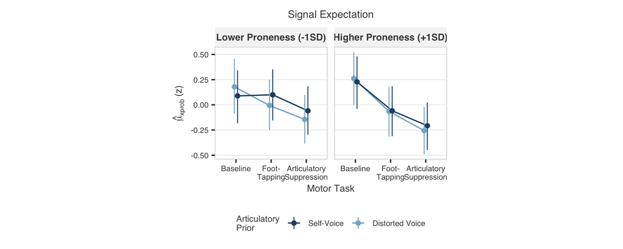

```r
p_xprob_sm = ggplot(ef_xprob, aes(x = Perturbation, y = emmean,
                                  colour = selfvoice, group = selfvoice)) +
  geom_line(linewidth = 0.7, position = voice_position) +
  geom_linerange(aes(ymin = lower.HPD, ymax = upper.HPD), linewidth = 0.5,
                 position = voice_position) +
  geom_point(size = 2, position = voice_position) +
  facet_wrap(~ Hallucination_Proneness, nrow = 1) +
  scale_colour_manual(values = c("Distorted" = "#82B3D1", "Self-Voice" = "#264E70"), limits = c("Self-Voice", "Distorted"), labels = c("Self-Voice", "Distorted Voice")) +
  scale_x_discrete(labels = c("None" = "Baseline", "Foot-Tapping" = "Foot-\nTapping",
                              "Art. Suppression" = "Articulatory\nSuppression")) +
  theme_paper() +
  labs(title = "Signal Expectation", x = "Motor Task",
       y = expression(hat(mu)[xprob] * " (z)"), colour = "Articulatory\nPrior")

print(p_xprob_sm)
```

### Signal Expectation: Conditional Cells by Motor Condition

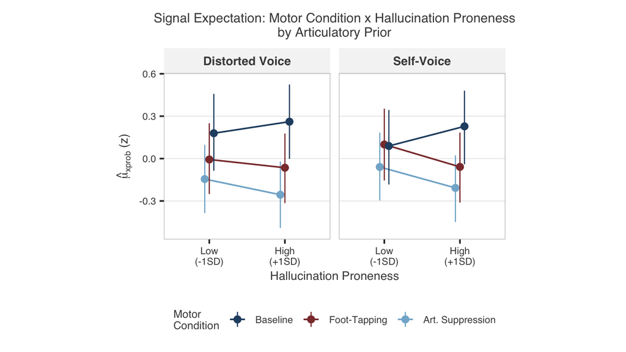

```r
ef_xprob_conditions = ef_xprob %>%
  mutate(
    Perturbation = factor(as.character(Perturbation),
                          levels = c("Art. Suppression", "Foot-Tapping", "None")),
    Hallucination_Proneness = factor(Hallucination_Proneness,
                                     levels = c("Lower Proneness (-1SD)", "Higher Proneness (+1SD)"))
  )

suppression_xprob = ef_xprob_conditions %>% filter(Perturbation == "Art. Suppression")
foot_tapping_xprob = ef_xprob_conditions %>% filter(Perturbation == "Foot-Tapping")
baseline_xprob = ef_xprob_conditions %>% filter(Perturbation == "None")
suppression_position = position_nudge(x = -0.06)
foot_tapping_position = position_nudge(x = 0)
baseline_position = position_nudge(x = 0.06)

p_xprob_cells_conditions = ggplot(ef_xprob_conditions,
                                  aes(x = Hallucination_Proneness, y = emmean, colour = Perturbation)) +
  geom_line(data = suppression_xprob, aes(group = Perturbation), linewidth = 0.7,
            position = suppression_position) +
  geom_linerange(data = suppression_xprob, aes(ymin = lower.HPD, ymax = upper.HPD),
                 linewidth = 0.5, position = suppression_position) +
  geom_point(data = suppression_xprob, size = 2.5, position = suppression_position) +
  geom_line(data = foot_tapping_xprob, aes(group = Perturbation), linewidth = 0.7,
            position = foot_tapping_position) +
  geom_linerange(data = foot_tapping_xprob, aes(ymin = lower.HPD, ymax = upper.HPD),
                 linewidth = 0.5, position = foot_tapping_position) +
  geom_point(data = foot_tapping_xprob, size = 2.5, position = foot_tapping_position) +
  geom_line(data = baseline_xprob, aes(group = Perturbation), linewidth = 0.7,
            position = baseline_position) +
  geom_linerange(data = baseline_xprob, aes(ymin = lower.HPD, ymax = upper.HPD),
                 linewidth = 0.5, position = baseline_position) +
  geom_point(data = baseline_xprob, size = 2.5, position = baseline_position) +
  facet_wrap(~ selfvoice, nrow = 1,
             labeller = as_labeller(c(
               "Distorted" = "Distorted Voice",
               "Self-Voice" = "Self-Voice"))) +
  scale_colour_manual(values = c("Art. Suppression" = "#82B3D1",
                                 "Foot-Tapping" = "#8B3A3A",
                                 "None" = "#264E70"),
                      limits = c("None", "Foot-Tapping", "Art. Suppression"),
                      labels = c("Baseline", "Foot-Tapping", "Art. Suppression")) +
  scale_x_discrete(labels = c("Lower Proneness (-1SD)" = "Low\n(-1SD)",
                              "Higher Proneness (+1SD)" = "High\n(+1SD)")) +
  scale_y_continuous(expand = expansion(mult = c(0.08, 0.08))) +
  theme_paper() +
  labs(title = "Signal Expectation: Motor Condition x Hallucination Proneness\nby Articulatory Prior",
       x = "Hallucination Proneness", y = expression(hat(mu)[xprob] * " (z)"),
       colour = "Motor\nCondition")

print(p_xprob_cells_conditions)
```

# 10. Manuscript Figure

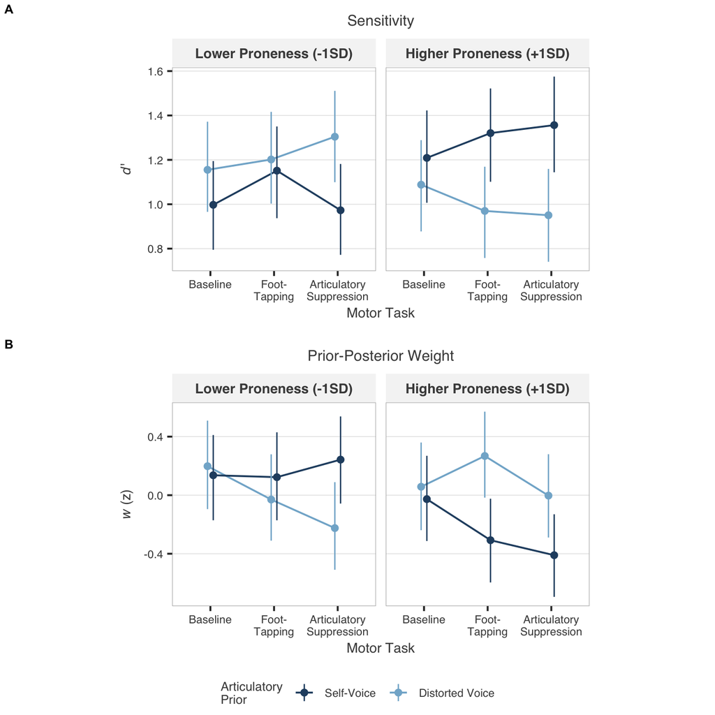

```r
fig4 = ggarrange(
  p_dprime_hl, p_ppw_sm,
  nrow = 2, ncol = 1, labels = c("A", "B"),
  font.label = list(size = 10, face = "bold"), align = "hv",
  common.legend = TRUE, legend = "bottom"
)
fig4
```

```r
ggsave("results/figures/figure_4_exp2.png",
       plot = fig4, width = 16, height = 18, units = "cm", dpi = 300, bg = "white")
ggsave("results/figures/figure_4_exp2.pdf",
       plot = fig4, width = 16, height = 18, units = "cm", bg = "white")
```